# 03_augment

Author

Group_23

# 03. Augment data

```r
library("tidyverse")
```

## 03.1. Load data from .tsv files

```r
prot_clin_cl <- read.delim("../data/02_dat_clean.tsv") |>
  as_tibble()
gene_metadata <- read.delim("../data/01_load_gene_metadata.tsv") |>
  as_tibble()
```

## 03.2. Data augmentation

### 03.2.1. Add intervals for Age at initial pathological diagnosis

For further analysis, it may be useful to group individuals by age intervals. This will allow us to elucidate if certain aspects regarding breast cancer are related to age. Before deciding on how to define the age intervals, it is useful to look at the age of the youngest and oldest individuals at the initial pathological diagnosis.

```r
prot_clin_cl |>
  summarize(
    min_age = min(Age.at.Initial.Pathologic.Diagnosis, na.rm = TRUE),
    max_age = max(Age.at.Initial.Pathologic.Diagnosis, na.rm = TRUE)
  )
```

```
# A tibble: 1 × 2
  min_age max_age
    <int>   <int>
1      30      88
```

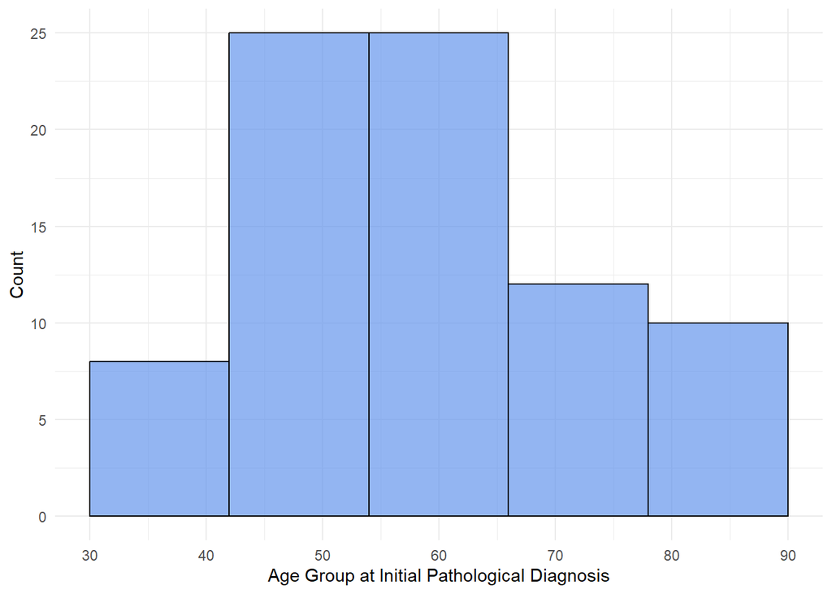

```r
ggplot(data = prot_clin_cl,
       mapping = aes(x = Age.at.Initial.Pathologic.Diagnosis)) +
  geom_histogram(bins =6, fill = "cornflowerblue", color = "black", alpha = 0.7) +
  theme_minimal() +
  labs(x = "Age Group at Initial Pathological Diagnosis",
       y = "Count") +
  scale_x_continuous(breaks = seq(30, 90, by = 10), limits = c(30, 90))
```

```r
prot_clin_cl <- prot_clin_cl |>
  rename(Age = Age.at.Initial.Pathologic.Diagnosis) |>
  mutate(
    Age.Ini.Diagnostic.group = case_when(
      is.na(Age) ~ "NA_character_",
      Age >= 30 & Age < 40 ~ "[30, 40)",
      Age >= 40 & Age < 50 ~ "[40, 50)",
      Age >= 50 & Age < 60 ~ "[50, 60)",
      Age >= 60 & Age < 70 ~ "[60, 70)",
      Age >= 70 & Age < 80 ~ "[70, 80)",
      Age >= 80 & Age < 90 ~ "[80, 90)",
    )
  ) |>
  rename(Age.at.Initial.Pathologic.Diagnosis = Age)
```

For good practices purpose, we use factors to represent the categorical data.

```r
prot_clin_cl <- prot_clin_cl |>
  mutate(Age.Ini.Diagnostic.group = factor(Age.Ini.Diagnostic.group,
                            levels =  c("[30, 40)",
                                        "[40, 50)",
                                        "[50, 60)",
                                        "[60, 70)",
                                        "[70, 80)",
                                        "[80, 90)")))
```

According to the [WHO](https://www.who.int/news-room/fact-sheets/detail/menopause), most women experience menopause between the ages of 45 and 55 years. To investigate whether there exist some correlation between certain types of cancer and being pre- or post- menopausal we also defined the following categories:

`[30, 45)`: Pre-menopausal

`[45, 55)`: Menopausal

`[55, 90)`: Post-menopausal

```r
prot_clin_cl <- prot_clin_cl %>%
  rename(Age = Age.at.Initial.Pathologic.Diagnosis) %>%
  mutate(
    Age.Menopausal.group = case_when(
      is.na(Age) ~"NA_character_",
      Age >= 30 & Age < 45 ~ "[30, 45)",
      Age >= 45 & Age < 55 ~ "[45, 55)",
      Age >= 55 & Age < 90 ~ "[55, 90)"
    )
  ) %>%
  rename(Age.at.Initial.Pathologic.Diagnosis = Age)
```

```r
prot_clin_cl <- prot_clin_cl %>%
  mutate(Age.Menopausal.group =  factor(Age.Menopausal.group,
                                        levels = c("[30, 45)",
                                                   "[45, 55)",
                                                   "[55, 90)")))
```

### 03.2.2. Targeting Triple-negative breast cancer (TNBC)

Given that TNBC tends to be more aggressive than other types of breast cancer and has no approved targeted treatments, it may be interesting to identify and analyze individuals suffering from TNBC. Therefore, we created a column to specifically target TNBC, encoding individuals as TNBC-positive or TNBC-negative. Before creating the new column, we check how many individuals have missing values for `ER.Status`, `PR.Status`, or `HER2.Final.Status` .

```r
prot_clin_cl |>
  filter(is.na(ER.Status) | is.na(PR.Status) | is.na(HER2.Final.Status))
```

```
# A tibble: 3 × 9,350
  Complete.TCGA.ID Gender Age.at.Initial.Pathologic.Diagno…¹ ER.Status PR.Status
  <chr>            <chr>                               <int> <chr>     <chr>
1 X263d3f.I.CPTAC  <NA>                                   NA <NA>      <NA>
2 blcdb9.I.CPTAC   <NA>                                   NA <NA>      <NA>
3 c4155b.C.CPTAC   <NA>                                   NA <NA>      <NA>
# ℹ abbreviated name: ¹Age.at.Initial.Pathologic.Diagnosis
# ℹ 9,345 more variables: HER2.Final.Status <chr>, Tumor <chr>, Node <chr>,
#   Node.Coded <chr>, Metastasis <chr>, AJCC.Stage <chr>,
#   Converted.Stage <chr>, Vital.State <int>, PAM50.mRNA <chr>,
#   NP_958782 <dbl>, NP_958785 <dbl>, NP_958786 <dbl>, NP_000436 <dbl>,
#   NP_958781 <dbl>, NP_958780 <dbl>, NP_958783 <dbl>, NP_958784 <dbl>,
#   NP_112598 <dbl>, NP_001611 <dbl>, NP_076965 <dbl>, NP_001367 <dbl>, …
```

The only individuals that have NA values for `ER.Status`, `PR.Status`, or `HER2.Final.Status` are the 3 healthy individuals. Since they do not suffer from cancer, it would not make sense to impute any value for them, so they will also have NA values for the `TNBC` column.

```r
prot_clin_cl <- prot_clin_cl |>
  rename(ER = ER.Status, PR = PR.Status, HER2 = HER2.Final.Status) |>
  mutate(
    TNBC = case_when(
      is.na(ER) | is.na(PR) | is.na(HER2) ~ NA_real_,
      ER == "Negative" & PR == "Negative" & HER2 == "Negative" ~ 1,
      TRUE ~ 0 # All other cases
    )
  )
```

### 03.2.3. ER/PR/HER2 status

TNBC is a specific case of the ER/PR/HER2 status, in which no receptors of these 3 types are found on the tumorous cells (hence, triple-negative). More background information on this can be found in `04_describe.qmd` section of this project. However, it might be interesting to study other combinations of these receptors as well. Therefore, we create a column that provides information about whether the individuals are positive or negative for `ER` , `PR`, and `HER2`. We encoded them as:

- 0 : TNBC
- 1: HER2
- 2 : PR
- 3 : ER
- 4 : ER/PR
- 5 : ER/HER2
- 6 : PR/HER2
- 7 : ER/PR/HER2
- “*”: ER/PR but equivocal results on the test for HER2

```r
prot_clin_cl <- prot_clin_cl |>
  mutate(
    ER_PR_HER2 = case_when(
      is.na(ER) | is.na(PR) | is.na(HER2) ~ NA_character_,
      ER == "Negative" & PR == "Negative" & HER2 == "Negative" ~ "0", #"TNBC",
      ER == "Negative" & PR == "Negative" & HER2 == "Positive" ~ "1", # "HER2",
      ER == "Negative" & PR == "Positive" & HER2 == "Negative" ~ "2", # "PR",
      ER == "Positive" & PR == "Negative" & HER2 == "Negative" ~ "3", #"ER",
      ER == "Positive" & PR == "Positive" & HER2 == "Negative" ~ "4", # "ER/PR",
      ER == "Positive" & PR == "Negative" & HER2 == "Positive" ~ "5", # "ER/HER2",
      ER == "Negative" & PR == "Positive" & HER2 == "Positive" ~ "6", #"PR/HER2",
      ER == "Positive" & PR == "Positive" & HER2 == "Positive" ~ "7", #"ER/PR/HER2"
      ER == "Positive" & PR == "Positive" & HER2 == "Equivocal" ~ "*" #"ER/PR but equivocal for                                                                         HER2"
    )
  )
```

```r
prot_clin_cl <- prot_clin_cl |>
  mutate(ER_PR_HER2 = factor(ER_PR_HER2,
                            levels =  c("0",
                                        "1",
                                        "2",
                                        "3",
                                        "4",
                                        "5",
                                        "6",
                                        "7",
                                        "*")))
```

### 03.2.4. Simplify AJCC stages

Our data has two columns regarding the AJCC classification of the extent of a cancer, `AJCC.Stage` and `Converted.Stage`, with the latter referring to the translation of information from one edition of the AJCC staging system to another. In order to simplify further analysis and gather all data regarding AJCC into just one column, we will simplify the AJCC stages to I, II, III, and IV. For example, “Stage I”, “Stage IA” and “Stage IB” will all be considered “Stage I”.

```r
prot_clin_cl <- prot_clin_cl |>
  mutate(
    AJCC.Simp = case_when(
      is.na(AJCC.Stage)  ~ NA_character_,
      str_detect(AJCC.Stage, "^Stage IV") ~ "Stage IV",
      str_detect(AJCC.Stage, "^Stage III") ~ "Stage III",
      str_detect(AJCC.Stage, "^Stage II") ~ "Stage II",
      str_detect(AJCC.Stage, "^Stage I") ~ "Stage I"
    )
  )
```

```r
prot_clin_cl <- prot_clin_cl |>
  mutate(AJCC.Simp = factor(AJCC.Simp,
                            levels =  c("Stage IV",
                                        "Stage III",
                                        "Stage II",
                                        "Stage I")))
```

### 03.2.5. Rename and encode Node.Coded column

The `Node.Coded` column will be renamed to get the name `Node_Cancer`. Additionally, the values that are coded as “Positive” will receive the value 1, and those coded as “Negative” will receive the value 0. These minor changes are with regard to further Differential Expression Analysis (`07_analysis_3.qmd`).

```r
prot_clin_cl <- prot_clin_cl |>
  rename(Node_Cancer = Node.Coded) |>
  mutate(
    Node_Cancer = case_when(
      Node_Cancer == "Positive"  ~ 1,
      Node_Cancer == "Negative" ~ 0
    )
  )
```

## 03.3. Relocate columns

Before proceeding further, we relocated the new columns before the proteomic columns.

```r
prot_clin_cl <- prot_clin_cl |>
  relocate(Age.Ini.Diagnostic.group , .after = Age.at.Initial.Pathologic.Diagnosis) |>
  relocate(Age.Menopausal.group, .after = Age.Ini.Diagnostic.group) |>
  relocate(TNBC, .after = HER2) |>
  relocate(ER_PR_HER2, .after = TNBC) |>
  relocate(AJCC.Simp, .after = Converted.Stage)
```

## 03.3. Drop redundant columns

Since we have created `AJCC.Simp` , there is no need for the `AJCC.Stage` and `Converted.Stage` columns, as they contain redundant information. Thus, we drop them.

```r
prot_clin_cl <- prot_clin_cl |>
  select(-AJCC.Stage,
         -Converted.Stage)
```

## 03.5. Save the new data in a .tsv file

```r
prot_clin_cl |>
  write_tsv(file = "../data/03_dat_aug.tsv")
```